```python
# This Python 3 environment comes with many helpful analytics libraries installed
# It is defined by the kaggle/python Docker image: https://github.com/kaggle/docker-python
# For example, here's several helpful packages to load

import numpy as np # linear algebra
import pandas as pd # data processing, CSV file I/O (e.g. pd.read_csv)

# Input data files are available in the read-only "../input/" directory
# For example, running this (by clicking run or pressing Shift+Enter) will list all files under the input directory

import os
for dirname, _, filenames in os.walk('/kaggle/input'):
    for filename in filenames:
        print(os.path.join(dirname, filename))

# You can write up to 20GB to the current directory (/kaggle/working/) that gets preserved as output when you create a version using "Save & Run All"
# You can also write temporary files to /kaggle/temp/, but they won't be saved outside of the current session
```

```
/kaggle/input/datasets/organizations/olistbr/brazilian-ecommerce/olist_customers_dataset.csv
/kaggle/input/datasets/organizations/olistbr/brazilian-ecommerce/olist_sellers_dataset.csv
/kaggle/input/datasets/organizations/olistbr/brazilian-ecommerce/olist_order_reviews_dataset.csv
/kaggle/input/datasets/organizations/olistbr/brazilian-ecommerce/olist_order_items_dataset.csv
/kaggle/input/datasets/organizations/olistbr/brazilian-ecommerce/olist_products_dataset.csv
/kaggle/input/datasets/organizations/olistbr/brazilian-ecommerce/olist_geolocation_dataset.csv
/kaggle/input/datasets/organizations/olistbr/brazilian-ecommerce/product_category_name_translation.csv
/kaggle/input/datasets/organizations/olistbr/brazilian-ecommerce/olist_orders_dataset.csv
/kaggle/input/datasets/organizations/olistbr/brazilian-ecommerce/olist_order_payments_dataset.csv
```

# Brazilian E-Commerce Marketplace Analysis

## 1. Understanding Marketplace Performance Through Data

🇬🇧 **English Version**  
E-commerce marketplaces generate large volumes of transactional data that can be used to better understand customer behavior, sales performance, logistics efficiency, and seller dynamics.

In this project, we analyze real-world transactional data from a Brazilian e-commerce marketplace in order to uncover key business insights. The dataset contains information about nearly **100,000 orders**, including customer reviews, product categories, delivery performance, seller activity, and geographic distribution.

The objective of this analysis is to transform raw marketplace data into **actionable business insights** that help answer important questions such as:

• How has marketplace revenue evolved over time?  
• Which product categories generate the most revenue?  
• How satisfied are customers with their purchases?  
• Does delivery performance influence customer reviews?  
• Which regions generate the highest sales?  
• How concentrated is revenue among sellers?

To answer these questions, the analysis combines **data preparation, exploratory data analysis, and data visualization** using Python tools such as Pandas, Matplotlib, and Seaborn.

By exploring these dimensions, this project aims to provide a comprehensive overview of the marketplace’s performance and identify key drivers of growth, customer satisfaction, and operational efficiency.\

🇫🇷 **Version Française**  
Les marketplaces de commerce électronique génèrent d’importants volumes de données transactionnelles qui peuvent être exploitées afin de mieux comprendre le comportement des clients, les performances commerciales, l’efficacité logistique ainsi que la dynamique des vendeurs.

Dans ce projet, nous analysons des données transactionnelles réelles provenant d'une marketplace de e-commerce brésilienne afin d'identifier des enseignements clés pour l'activité. Le jeu de données contient des informations sur près de 100 000 commandes, incluant notamment les avis clients, les catégories de produits, les performances de livraison, l'activité des vendeurs ainsi que la répartition géographique des ventes.

L'objectif de cette analyse est de transformer des données brutes issues de la marketplace en insights exploitables pour la prise de décision, permettant de répondre à plusieurs questions importantes :

• Comment le chiffre d'affaires de la marketplace a-t-il évolué dans le temps ? • Quelles catégories de produits génèrent le plus de revenus ? • Dans quelle mesure les clients sont-ils satisfaits de leurs achats ? • Les performances de livraison influencent-elles les avis clients ? • Quelles régions génèrent le plus de ventes ? • Dans quelle mesure les revenus sont-ils concentrés entre les vendeurs ?

Pour répondre à ces questions, l’analyse combine préparation des données, analyse exploratoire et visualisation des données à l’aide d’outils Python tels que Pandas, Matplotlib et Seaborn.

En explorant ces différentes dimensions, ce projet vise à fournir une vue d’ensemble complète des performances de la marketplace et à identifier les principaux facteurs de croissance, de satisfaction client et d’efficacité opérationnelle.

## 2. Business Understanding

🇬🇧 **English Version**  
Online marketplaces rely heavily on data to understand customer behavior, optimize logistics, and improve platform performance.

From a business perspective, several key questions arise when analyzing a marketplace dataset:

• How is the marketplace performing in terms of revenue and order growth?  
• Which product categories contribute the most to overall revenue?  
• How satisfied are customers with their purchases?  
• Does delivery performance influence customer satisfaction?  
• Which geographic regions generate the most revenue?  
• Is the marketplace dependent on a small number of sellers, or is revenue distributed across many sellers?

Answering these questions can help marketplace operators improve strategic decisions related to logistics, marketing, product assortment, and seller management.

The goal of this analysis is therefore to explore these dimensions using data and extract insights that could support better decision-making.

🇫🇷 **Version Française**  
Les marketplaces en ligne s'appuient fortement sur les données afin de mieux comprendre le comportement des clients, optimiser les opérations logistiques et améliorer les performances globales de la plateforme.

D'un point de vue métier, plusieurs questions clés se posent lors de l'analyse d'un jeu de données provenant d'une marketplace :

• Comment la marketplace performe-t-elle en termes de chiffre d'affaires et de croissance des commandes ? • Quelles catégories de produits contribuent le plus au chiffre d'affaires global ? • Dans quelle mesure les clients sont-ils satisfaits de leurs achats ? • Les performances de livraison influencent-elles la satisfaction des clients ? • Quelles régions géographiques génèrent le plus de revenus ? • La marketplace dépend-elle d'un petit nombre de vendeurs ou les revenus sont-ils répartis entre de nombreux vendeurs ?

Répondre à ces questions peut aider les opérateurs de la marketplace à améliorer leurs décisions stratégiques en matière de logistique, marketing, gestion de l'offre produits et pilotage de l'écosystème des vendeurs.

L'objectif de cette analyse est donc d'explorer ces différentes dimensions à partir des données afin d'en extraire des enseignements pertinents pouvant soutenir une prise de décision plus éclairée.

## 3. Data Understanding

🇬🇧 **English Version**  
Before starting the analysis, it is important to understand the structure and content of the dataset.

The Brazilian E-Commerce dataset is composed of multiple relational tables describing different aspects of marketplace activity, including orders, customers, products, sellers, payments, reviews, and geolocation information.

Each table represents a specific component of the marketplace ecosystem and can be linked using common identifiers such as `order_id`, `customer_id`, or `product_id`.

### Main Tables Used in This Analysis

The following datasets are used throughout this analysis:

**Orders dataset** Contains information about each order placed on the marketplace, including purchase timestamps, delivery status, and estimated delivery dates.

**Order Items dataset** Provides detailed information about products purchased in each order, including product price, freight cost, and seller identifiers.

**Customers dataset** Includes customer identifiers and geographic information, allowing us to analyze regional sales patterns.

**Products dataset** Contains product-related information such as product categories.

**Order Reviews dataset** Includes customer review scores and feedback related to each order.

**Sellers dataset** Provides information about the sellers participating in the marketplace.

### Dataset Structure

These datasets are connected through several key identifiers:

| **Key** | **Description** |
| --- | --- |
| order_id | Unique identifier for each order |
| customer_id | Identifier linking orders to customers |
| product_id | Identifier for each product |
| seller_id | Identifier for each seller |

By combining these tables, we can build a comprehensive analytical dataset that allows us to analyze marketplace performance across multiple dimensions.

🇫🇷 **Version Française**  
Avant de commencer l’analyse, il est important de comprendre la structure et le contenu du jeu de données.

Le dataset Brazilian E-Commerce est composé de plusieurs tables relationnelles décrivant différents aspects de l'activité de la marketplace, notamment les commandes, les clients, les produits, les vendeurs, les paiements, les avis clients et les informations de géolocalisation.

Chaque table représente un composant spécifique de l'écosystème de la marketplace et peut être reliée aux autres à l'aide d'identifiants communs tels que order_id, customer_id ou product_id.

### Tables principales utilisées dans cette analyse

Les jeux de données suivants sont utilisés tout au long de cette analyse :

**Orders dataset** Contient des informations sur chaque commande passée sur la marketplace, notamment les dates d'achat, le statut de la commande, ainsi que les dates de livraison estimées.

**Order Items dataset** Fournit des informations détaillées sur les produits achetés dans chaque commande, notamment le prix des produits, le coût de livraison et les identifiants des vendeurs.

**Customers dataset** Inclut les identifiants des clients ainsi que des informations géographiques, permettant d'analyser la répartition régionale des ventes.

**Products dataset** Contient des informations relatives aux produits, notamment les catégories de produits.

**Order Reviews dataset** Inclut les notes et avis laissés par les clients pour chaque commande.

**Sellers dataset** Fournit des informations sur les vendeurs présents sur la marketplace.

### Structure du dataset

Ces différents jeux de données sont reliés entre eux grâce à plusieurs identifiants clés :

| **Key** | **Description** |
| --- | --- |
| order_id | Unique identifier for each order |
| customer_id | Identifier linking orders to customers |
| product_id | Identifier for each product |
| seller_id | Identifier for each seller |

En combinant ces différentes tables, il est possible de construire un jeu de données analytique complet permettant d’analyser les performances de la marketplace selon plusieurs dimensions.

## 4. Data Cleaning

🇬🇧 **English Version**  
Before performing the analysis, the dataset required several cleaning and preparation steps to ensure data consistency and usability.

Because the dataset is composed of multiple relational tables, the preparation process involved handling missing values, converting data types, and merging datasets into a unified analytical table.

### Handling Missing Values

Several columns contained missing values, particularly those related to delivery and review information. These missing values were expected because not all orders reach the same stages of the order lifecycle (for example, canceled orders may not have delivery timestamps).

For the purposes of this analysis:

- Missing delivery dates were left unchanged when they represented incomplete orders.
- Review data was merged when available to analyze customer satisfaction.

### Converting Data Types

Date columns were converted to proper datetime format to allow time-based analysis.

The following columns were converted:

- order_purchase_timestamp
- order_approved_at
- order_delivered_carrier_date
- order_delivered_customer_date
- order_estimated_delivery_date

This conversion enables operations such as calculating delivery delays and analyzing monthly trends.

### Creating Derived Variables

Additional variables were created to support the analysis.

**Revenue** Revenue was calculated by combining the product price and freight value for each order item:

Revenue = price + freight_value

This allows the estimation of total marketplace revenue.

**Delivery Delay** Delivery delay was calculated as the difference between the actual delivery date and the estimated delivery date.

Delivery Delay = actual_delivery_date − estimated_delivery_date

Negative values indicate that the order was delivered earlier than expected.

### Building the Analytical Dataset

To perform the analysis, several tables were merged into a single dataset called `sales`. This dataset combines information from:

- orders
- order items
- customers
- products
- reviews

By consolidating these datasets, it becomes possible to analyze marketplace performance across multiple dimensions such as time, product categories, geography, and seller activity.

🇫🇷 **Version Française**  
Avant de réaliser l'analyse, le jeu de données a nécessité plusieurs étapes de nettoyage et de préparation afin de garantir la cohérence et l'exploitabilité des données.

Étant donné que le dataset est composé de plusieurs tables relationnelles, le processus de préparation a consisté à gérer les valeurs manquantes, convertir certains types de données et fusionner les différentes tables afin de construire une table analytique unifiée.

### Gestion des valeurs manquantes

Plusieurs colonnes contenaient des valeurs manquantes, notamment celles liées aux informations de livraison et aux avis clients. Ces valeurs manquantes étaient attendues, car toutes les commandes ne passent pas par les mêmes étapes du cycle de vie d’une commande (par exemple, les commandes annulées ne disposent pas toujours d’informations de livraison).

Dans le cadre de cette analyse :

- Les dates de livraison manquantes ont été conservées lorsqu'elles correspondaient à des commandes incomplètes.
- Les données d'avis clients ont été intégrées lorsque celles-ci étaient disponibles afin d'analyser la satisfaction des clients.

### Conversion des types de données

Les colonnes contenant des dates ont été converties au format datetime afin de permettre des analyses temporelles.

Les colonnes suivantes ont été converties :

- order_purchase_timestamp
- order_approved_at
- order_delivered_carrier_date
- order_delivered_customer_date
- order_estimated_delivery_date

Cette conversion permet notamment d’effectuer des opérations telles que le calcul des délais de livraison ou l'analyse des tendances mensuelles.

### Création de variables dérivées

Des variables supplémentaires ont été créées afin de faciliter l’analyse.

**Revenue** Le revenu a été calculé en combinant le prix du produit et les frais de livraison pour chaque article commandé :

Revenue = price + freight_value

Ce calcul permet d’estimer le chiffre d’affaires total généré par la marketplace.

**Delivery Delay** Le délai de livraison a été calculé comme la différence entre la date réelle de livraison et la date de livraison estimée.

Delivery Delay = actual_delivery_date − estimated_delivery_date

Des valeurs négatives indiquent que la commande a été livrée plus tôt que prévu.

### Construction du jeu de données analytique

Afin de réaliser l'analyse, plusieurs tables ont été fusionnées pour créer un jeu de données unique appelé sales. Ce dataset combine des informations provenant de :

- orders
- order_items
- customers
- products
- reviews

En consolidant ces différentes sources de données, il devient possible d'analyser les performances de la marketplace selon plusieurs dimensions telles que le temps, les catégories de produits, la géographie ou encore l'activité des vendeurs.

## 5. Exploratory Data Analysis

🇬🇧 **English Version**  
Exploratory Data Analysis (EDA) aims to identify patterns, trends, and relationships within the dataset. By analyzing different aspects of the marketplace, we can better understand its growth, customer behavior, and operational performance.

This section explores several key dimensions of the marketplace:

- marketplace growth over time
- revenue evolution
- product category performance
- customer satisfaction
- delivery performance
- geographic sales distribution
- seller ecosystem structure

🇫🇷 Version Française  
L'analyse exploratoire des données (EDA) vise à identifier les schémas, tendances et relations présents dans le jeu de données. En analysant différents aspects de la marketplace, nous pouvons mieux comprendre sa croissance, le comportement des clients ainsi que ses performances opérationnelles.

Cette section explore plusieurs dimensions clés de la marketplace :

- l'évolution de l'activité de la marketplace dans le temps
- l'évolution du chiffre d'affaires
- les performances des différentes catégories de produits
- la satisfaction des clients
- les performances de livraison
- la répartition géographique des ventes
- la structure de l'écosystème des vendeurs

## 6. Insights and Findings

🇬🇧 **English Version**  
The exploratory analysis reveals several important insights about the structure and performance of the Brazilian e-commerce marketplace.

### Marketplace Growth

The number of orders increased significantly between 2017 and 2018, indicating strong marketplace growth during this period. This suggests increasing platform adoption and rising customer demand.

### Revenue Performance

Total marketplace revenue reached approximately **15.8 million BRL** across nearly **100,000 orders**. The **average order value is approximately 161 BRL**, indicating that revenue growth is primarily driven by an increase in order volume rather than higher spending per transaction.

### Product Category Performance

Several product categories dominate marketplace revenue. The top-performing categories include:

- Health & Beauty
- Watches & Gifts
- Bed, Bath & Table
- Sports & Leisure
- Computer Accessories

These categories represent everyday consumer goods and popular gift items, which tend to generate consistent purchasing behavior.

### Customer Satisfaction

Customer reviews indicate a high level of satisfaction on the platform. More than **75% of review scores are rated 4 or 5 stars**, suggesting that the majority of customers are satisfied with their purchasing experience.

### Delivery Performance

Delivery performance appears to have a measurable impact on customer satisfaction. Orders associated with higher review scores tend to be delivered earlier relative to the estimated delivery date, suggesting that faster deliveries contribute to higher customer ratings.

### Geographic Distribution

Marketplace revenue is highly concentrated in economically developed regions of Brazil. The state of **São Paulo generates approximately 37% of total revenue**, followed by other major states such as Rio de Janeiro and Minas Gerais.

### Seller Ecosystem

The marketplace includes approximately **3,095 active sellers**, indicating a diverse seller ecosystem. The top seller generates roughly **1.6% of total marketplace revenue**, suggesting that the platform is not overly dependent on a single seller and that revenue is distributed across many participants.

🇫🇷 **Version Française**  
L’analyse exploratoire met en évidence plusieurs enseignements importants concernant la structure et les performances de la marketplace de e-commerce brésilienne.

### Croissance de la marketplace

Le nombre de commandes a fortement augmenté entre 2017 et 2018, ce qui indique une croissance significative de la marketplace durant cette période. Cela suggère une adoption croissante de la plateforme ainsi qu'une augmentation de la demande des clients.

### Performance du chiffre d’affaires

Le chiffre d’affaires total de la marketplace atteint environ **15,8 millions de BRL** pour près de **100 000 commandes**. Le **panier moyen est d’environ 161 BRL**, ce qui indique que la croissance du chiffre d’affaires est principalement liée à l’augmentation du volume de commandes plutôt qu’à une hausse du montant dépensé par transaction.

### Performance des catégories de produits

Certaines catégories de produits dominent le chiffre d'affaires de la marketplace. Les catégories les plus performantes incluent notamment :

- Health & Beauty
- Watches & Gifts
- Bed, Bath & Table
- Sports & Leisure
- Computer Accessories

Ces catégories correspondent principalement à des biens de consommation courante ainsi qu'à des produits fréquemment achetés comme cadeaux, ce qui favorise des comportements d'achat réguliers.

### Satisfaction des clients

Les avis clients indiquent un niveau de satisfaction globalement élevé sur la plateforme. Plus de 75 % des avis attribuent une note de 4 ou 5 étoiles, ce qui suggère que la majorité des clients sont satisfaits de leur expérience d'achat.

### Performance de la livraison

Les performances de livraison semblent avoir un impact mesurable sur la satisfaction des clients. Les commandes associées aux notes les plus élevées sont généralement livrées plus tôt que la date estimée, ce qui suggère que des livraisons rapides contribuent à améliorer l'expérience client.

### Répartition géographique

Le chiffre d'affaires de la marketplace est fortement concentré dans les régions économiquement les plus développées du Brésil. L'État de **São Paulo génère environ 37 % du chiffre d’affaires total**, suivi par d'autres États importants tels que Rio de Janeiro et Minas Gerais.

### Ecosystème des vendeurs

La marketplace compte environ **3 095 vendeurs actifs**, ce qui indique un écosystème relativement diversifié. Le vendeur le plus performant génère environ **1,6 % du chiffre d’affaires total**, ce qui suggère que la plateforme ne dépend pas excessivement d'un seul vendeur et que les revenus sont répartis entre un grand nombre de participants.

## 7. Business Recommendations

🇬🇧 **English Version**  
Based on the insights derived from the analysis, several strategic opportunities can be identified to improve marketplace performance and customer experience.

### Improve Logistics and Delivery Performance

Delivery speed appears to play a key role in customer satisfaction. Orders delivered earlier than the estimated delivery date tend to receive higher review scores.

Improving logistics efficiency and reducing delivery delays could further enhance customer satisfaction and strengthen trust in the platform.

### Focus on High-Performing Product Categories

Certain product categories such as **Health & Beauty**, **Watches & Gifts**, and **Home-related products** generate a significant share of marketplace revenue.

The platform could increase revenue by:

- prioritizing these categories in marketing campaigns
- improving product visibility for these segments
- expanding product offerings within these high-demand categories

### Strengthen Presence in High-Revenue Regions

Sales are highly concentrated in economically developed regions, particularly **São Paulo**, which represents the largest share of marketplace revenue.

Strategic marketing initiatives and logistics optimization in these regions could further boost marketplace growth.

At the same time, expanding outreach in underrepresented regions may unlock new customer segments.

### Support a Diverse Seller Ecosystem

The platform could continue supporting sellers through:

- better analytics tools
- improved onboarding processes
- marketing support for smaller sellers

### Continue Leveraging Customer Feedback

Customer reviews provide valuable insights into customer experience and operational performance.

By continuously monitoring review data, the marketplace can quickly identify potential issues related to delivery, product quality, or seller performance and address them proactively.

🇫🇷 **Version Française**  
Sur la base des enseignements issus de l'analyse, plusieurs opportunités stratégiques peuvent être identifiées afin d'améliorer les performances de la marketplace et l'expérience client.

### Améliorer les performances logistiques et de livraison

La rapidité de livraison semble jouer un rôle déterminant dans la satisfaction des clients. Les commandes livrées avant la date estimée reçoivent généralement de meilleures notes.

L'amélioration de l'efficacité logistique et la réduction des délais de livraison pourraient ainsi renforcer la satisfaction des clients et accroître la confiance envers la plateforme.

### Se concentrer sur les catégories de produits les plus performantes

Certaines catégories de produits telles que **Health & Beauty**, **Watches & Gifts** et les **produits liés à la maison** génèrent une part importante du chiffre d'affaires de la marketplace.

La plateforme pourrait augmenter ses revenus en :

- donnant davantage de visibilité à ces catégories dans les campagnes marketing
- améliorant la mise en avant de ces produits sur la plateforme
- élargissant l'offre de produits dans ces segments à forte demande

### Renforcer la présence dans les régions à fort potentiel de revenus

Les ventes sont fortement concentrées dans les régions économiquement développées, en particulier l'état de **São Paulo**, qui représente la plus grande part du chiffre d'affaires de la marketplace.

Des initiatives marketing ciblées et une optimisation logistique dans ces régions pourraient contribuer à accélérer la croissance de la plateforme.

Par ailleurs, développer la présence de la marketplace dans des régions moins représentées pourrait permettre d'atteindre de nouveaux segments de clientèle.

### Soutenir un écosystème de vendeurs diversifié

La marketplace pourrait continuer à soutenir les vendeurs grâce à :

- des outils d'analyse et de pilotage plus performants
- des processus d'intégration (onboarding) améliorés
- un soutien marketing pour les vendeurs de plus petite taille

### Continuer à exploiter les retours clients

Les avis clients constituent une source précieuse d'informations sur l'expérience utilisateur et les performances opérationnelles.

En surveillant régulièrement ces données, la marketplace peut identifier rapidement les éventuels problèmes liés à la livraison, à la qualité des produits ou aux performances des vendeurs, et mettre en place des actions correctives de manière proactive.

```python
import pandas as pd
import numpy as np
import matplotlib.pyplot as plt
import seaborn as sns
```

```python
customers = pd.read_csv("../input/datasets/organizations/olistbr/brazilian-ecommerce/olist_customers_dataset.csv")
orders = pd.read_csv("../input/datasets/organizations/olistbr/brazilian-ecommerce/olist_orders_dataset.csv")
order_items = pd.read_csv("../input/datasets/organizations/olistbr/brazilian-ecommerce/olist_order_items_dataset.csv")
order_payments = pd.read_csv("../input/datasets/organizations/olistbr/brazilian-ecommerce/olist_order_payments_dataset.csv")
order_reviews = pd.read_csv("../input/datasets/organizations/olistbr/brazilian-ecommerce/olist_order_reviews_dataset.csv")
products = pd.read_csv("../input/datasets/organizations/olistbr/brazilian-ecommerce/olist_products_dataset.csv")
sellers = pd.read_csv("../input/datasets/organizations/olistbr/brazilian-ecommerce/olist_sellers_dataset.csv")
```

```python
orders.head()
```

|  | order_id | customer_id | order_status | order_purchase_timestamp | order_approved_at | order_delivered_carrier_date | order_delivered_customer_date | order_estimated_delivery_date |
| --- | --- | --- | --- | --- | --- | --- | --- | --- |
| 0 | e481f51cbdc54678b7cc49136f2d6af7 | 9ef432eb6251297304e76186b10a928d | delivered | 2017-10-02 10:56:33 | 2017-10-02 11:07:15 | 2017-10-04 19:55:00 | 2017-10-10 21:25:13 | 2017-10-18 00:00:00 |
| 1 | 53cdb2fc8bc7dce0b6741e2150273451 | b0830fb4747a6c6d20dea0b8c802d7ef | delivered | 2018-07-24 20:41:37 | 2018-07-26 03:24:27 | 2018-07-26 14:31:00 | 2018-08-07 15:27:45 | 2018-08-13 00:00:00 |
| 2 | 47770eb9100c2d0c44946d9cf07ec65d | 41ce2a54c0b03bf3443c3d931a367089 | delivered | 2018-08-08 08:38:49 | 2018-08-08 08:55:23 | 2018-08-08 13:50:00 | 2018-08-17 18:06:29 | 2018-09-04 00:00:00 |
| 3 | 949d5b44dbf5de918fe9c16f97b45f8a | f88197465ea7920adcdbec7375364d82 | delivered | 2017-11-18 19:28:06 | 2017-11-18 19:45:59 | 2017-11-22 13:39:59 | 2017-12-02 00:28:42 | 2017-12-15 00:00:00 |
| 4 | ad21c59c0840e6cb83a9ceb5573f8159 | 8ab97904e6daea8866dbdbc4fb7aad2c | delivered | 2018-02-13 21:18:39 | 2018-02-13 22:20:29 | 2018-02-14 19:46:34 | 2018-02-16 18:17:02 | 2018-02-26 00:00:00 |

```python
orders.info()
```

```
<class 'pandas.core.frame.DataFrame'>
RangeIndex: 99441 entries, 0 to 99440
Data columns (total 8 columns):
 #   Column                         Non-Null Count  Dtype
---  ------                         --------------  -----
 0   order_id                       99441 non-null  object
 1   customer_id                    99441 non-null  object
 2   order_status                   99441 non-null  object
 3   order_purchase_timestamp       99441 non-null  object
 4   order_approved_at              99281 non-null  object
 5   order_delivered_carrier_date   97658 non-null  object
 6   order_delivered_customer_date  96476 non-null  object
 7   order_estimated_delivery_date  99441 non-null  object
dtypes: object(8)
memory usage: 6.1+ MB
```

```python
orders.shape
```

```
(99441, 8)
```

```python
order_items.shape
```

```
(112650, 7)
```

```python
order_payments.shape
```

```
(103886, 5)
```

```python
order_reviews.shape
```

```
(99224, 7)
```

```python
products.shape
```

```
(32951, 9)
```

```python
sellers.shape
```

```
(3095, 4)
```

```python
orders.isnull().sum()
products.isnull().sum()
order_reviews.isnull().sum()
```

```
review_id                      0
order_id                       0
review_score                   0
review_comment_title       87656
review_comment_message     58247
review_creation_date           0
review_answer_timestamp        0
dtype: int64
```

**Understanding the central table**  
In this dataset, the most important table is :

"orders"

It contains:

- order dates
- delivery dates
- order status
- customer information

This is the backbone of the dataset.

**Comprendre la table centrale**  
Dans ce dataset, la table la plus importante est : "orders"

Elle contient :

- les dates de commande
- les dates de livraison
- le statut de la commande
- le client

C’est la colonne vertébrale du dataset.

-**Convert dates**

-**Convertir les dates**

```python
orders["order_purchase_timestamp"] = pd.to_datetime(orders["order_purchase_timestamp"])
orders["order_delivered_customer_date"] = pd.to_datetime(orders["order_delivered_customer_date"])
```

**Let's look at the order period.**

**Regardons la période des commandes.**

```python
orders["order_purchase_timestamp"].min()
orders["order_purchase_timestamp"].max()
```

```
Timestamp('2018-10-17 17:30:18')
```

**Let's now look at the distribution of order statuses.**

**Voyons maintenant la répartition "distribution" des statuts de commande**

```python
orders["order_status"].value_counts()
```

```
order_status
delivered      96478
shipped         1107
canceled         625
unavailable      609
invoiced         314
processing       301
created            5
approved           2
Name: count, dtype: int64
```

**Let's create our first graph to see the evolution of orders per month.**

**Elaborons notre premier graphique afin de voir l’évolution des commandes par mois.**

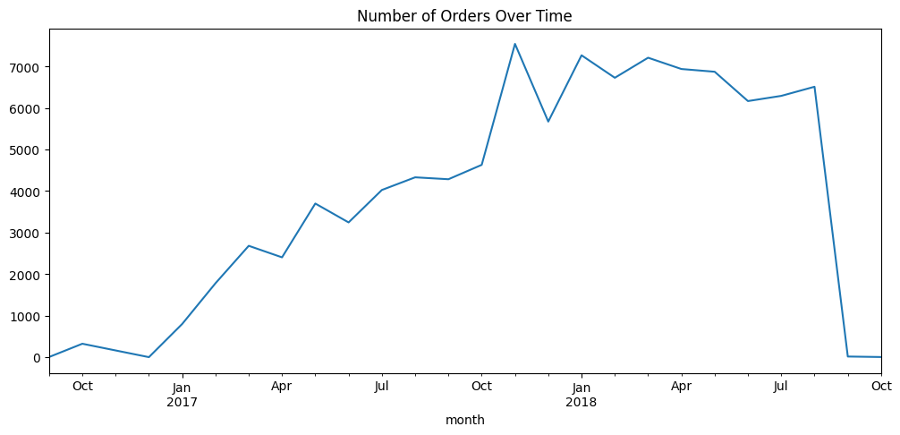

```python
orders["month"] = orders["order_purchase_timestamp"].dt.to_period("M")

orders_by_month = orders.groupby("month").size()

orders_by_month.plot(figsize=(12,5))
plt.title("Number of Orders Over Time")
plt.show()
```

**Evolution of the number of orders over time**  
This is one of the most important analyses for an e-commerce business.

**Evolution du nombre de commandes dans le temps**  
C'est l'une des analyses les plus importantes pour un e-commerce.

```python
# We are going to create a month column
# Nous allons créer une colonne mois

orders["order_purchase_month"] = orders["order_purchase_timestamp"].dt.to_period("M")
```

```python
# Calculating the number of orders per month
# Calcul du nombre de commandes par mois

orders_per_month = orders.groupby("order_purchase_month").size()
```

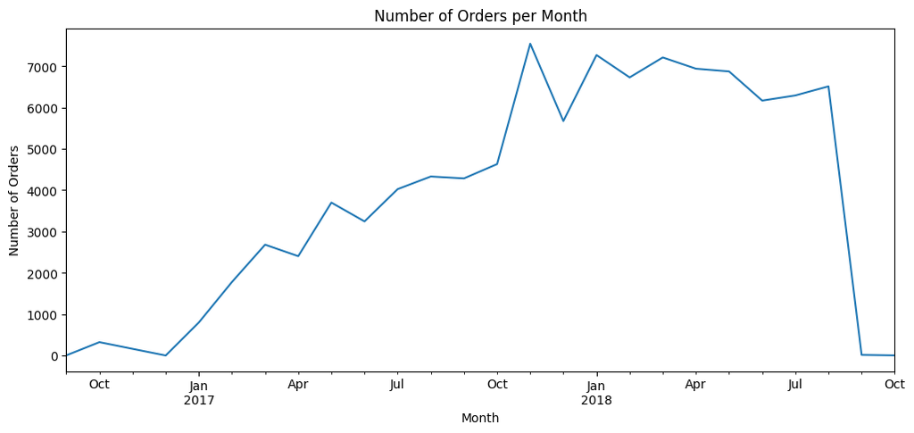

```python
plt.figure(figsize=(12,5))

orders_per_month.plot()

plt.title("Number of Orders per Month")
plt.xlabel("Month")
plt.ylabel("Number of Orders")

plt.show()
```

# **Trend Interpretation**

We observe a gradual increase in order volume between 2017 and mid-2018.

This could indicate:

- growth of the marketplace
- an increase in the number of sellers
- growing adoption of e-commerce
- a specific peak

In e-commerce, this type of peak can correspond to:

- promotions
- commercial events
- or seasonality

However, caution is advised here. The dataset ends in 2018, and the apparent decline observed is likely due to the data series ceasing at that time rather than a real decrease in market activity. It may simply stem from the fact that the data does not cover the entire period.

#### **Summary**

--

# **Interprétation de la tendance**

On observe une croissance progressive du volume de commandes entre 2017 et mi-2018

Cela peut indiquer :

- une croissance de la marketplace
- une augmentation du nombre de vendeurs
- une adoption croissante du e-commerce
- une pic particulier

Dans l'e-commerce, ce genre de pic peut correspondre à :

- des promotions
- des événements commerciaux
- ou une saisonnalité

Mais ici il faut être prudent, en effet, le dataset s'arrête en 2018, le déclin apparent observé, est probablement dû à l'arrêt de la série de données à cette période plutôt qu'à une baisse réelle de l'activité du marché, et peut simplement venir du fait que les données ne couvrent pas toute la période.

#### **Order Volume Analysis**

But what's really interesting to look at is, of course, the revenue. For this, we'll use the "order_items" table  
Because it contains the product prices and shipping costs

#### **Analyse du volume de commandes**

Mais ce qui est intéressant à observer, c'est bien entendu le chiffre d'affaires, pour cela, nous allons utiliser la table :  
"order_items"  
Car elle contient les prix des produits et les frais de livraison

#### **Next step — let's explore the order_items table**

#### **Étape suivante — explorons la table order_items**

```python
order_items.head()
```

|  | order_id | order_item_id | product_id | seller_id | shipping_limit_date | price | freight_value |
| --- | --- | --- | --- | --- | --- | --- | --- |
| 0 | 00010242fe8c5a6d1ba2dd792cb16214 | 1 | 4244733e06e7ecb4970a6e2683c13e61 | 48436dade18ac8b2bce089ec2a041202 | 2017-09-19 09:45:35 | 58.90 | 13.29 |
| 1 | 00018f77f2f0320c557190d7a144bdd3 | 1 | e5f2d52b802189ee658865ca93d83a8f | dd7ddc04e1b6c2c614352b383efe2d36 | 2017-05-03 11:05:13 | 239.90 | 19.93 |
| 2 | 000229ec398224ef6ca0657da4fc703e | 1 | c777355d18b72b67abbeef9df44fd0fd | 5b51032eddd242adc84c38acab88f23d | 2018-01-18 14:48:30 | 199.00 | 17.87 |
| 3 | 00024acbcdf0a6daa1e931b038114c75 | 1 | 7634da152a4610f1595efa32f14722fc | 9d7a1d34a5052409006425275ba1c2b4 | 2018-08-15 10:10:18 | 12.99 | 12.79 |
| 4 | 00042b26cf59d7ce69dfabb4e55b4fd9 | 1 | ac6c3623068f30de03045865e4e10089 | df560393f3a51e74553ab94004ba5c87 | 2017-02-13 13:57:51 | 199.90 | 18.14 |

```python
order_items.info()
```

```
<class 'pandas.core.frame.DataFrame'>
RangeIndex: 112650 entries, 0 to 112649
Data columns (total 7 columns):
 #   Column               Non-Null Count   Dtype
---  ------               --------------   -----
 0   order_id             112650 non-null  object
 1   order_item_id        112650 non-null  int64
 2   product_id           112650 non-null  object
 3   seller_id            112650 non-null  object
 4   shipping_limit_date  112650 non-null  object
 5   price                112650 non-null  float64
 6   freight_value        112650 non-null  float64
dtypes: float64(2), int64(1), object(4)
memory usage: 6.0+ MB
```

```python
order_items.shape
```

```
(112650, 7)
```

### **Les colonnes importantes**

Dans order_items on obtient quelque chose comme :

| **colonne** | **signification** |
| --- | --- |
| order_id | identifiant commande |
| order_item_id | numéro produit dans la commande |
| product_id | identifiant produit |
| seller_id | vendeur |
| shipping_limit_date | limite expédition |
| price | prix produit |
| freight_value | coût livraison |

Donc apparemment :

- price = revenu produit
- freight_value = frais de livraison

```python
# Now we need to rebuild the sales table by linking orders and order_items.
# Maintenant il nous faut reconstruire la table des ventes en reliant orders et order_items

sales = pd.merge(
    orders,
    order_items,
    on="order_id",
    how="inner"
)
```

```python
# We check the size of the new table
# On vérifie la taille de la nouvelle table

sales.shape
```

```
(112650, 16)
```

### **1. The sales table is essential; it will contain:**

- order date
- customer
- product
- price
- delivery
- status

### **2. This will allow us to analyze:**

- revenue
- products sold
- popular categories
- customer satisfaction
- logistics performance

The sales table is the pivot table, the main table for our analysis

--

### **1. La table sales est essentielle elle va contenir**

- date commande
- client
- produit
- prix
- livraison
- statut

### **2. Ainsi nous pourrons analyser :**

- le chiffre d'affaires
- les produits vendus
- les catégories populaires
- la satisfaction client
- les performances logistique

Sales est la table pivot, la table principale de notre analyse

```python
# Checking the created table
# Vérification de la table créée

sales.head()
```

|  | order_id | customer_id | order_status | order_purchase_timestamp | order_approved_at | order_delivered_carrier_date | order_delivered_customer_date | order_estimated_delivery_date | month | order_purchase_month | order_item_id | product_id | seller_id | shipping_limit_date | price | freight_value |
| --- | --- | --- | --- | --- | --- | --- | --- | --- | --- | --- | --- | --- | --- | --- | --- | --- |
| 0 | e481f51cbdc54678b7cc49136f2d6af7 | 9ef432eb6251297304e76186b10a928d | delivered | 2017-10-02 10:56:33 | 2017-10-02 11:07:15 | 2017-10-04 19:55:00 | 2017-10-10 21:25:13 | 2017-10-18 00:00:00 | 2017-10 | 2017-10 | 1 | 87285b34884572647811a353c7ac498a | 3504c0cb71d7fa48d967e0e4c94d59d9 | 2017-10-06 11:07:15 | 29.99 | 8.72 |
| 1 | 53cdb2fc8bc7dce0b6741e2150273451 | b0830fb4747a6c6d20dea0b8c802d7ef | delivered | 2018-07-24 20:41:37 | 2018-07-26 03:24:27 | 2018-07-26 14:31:00 | 2018-08-07 15:27:45 | 2018-08-13 00:00:00 | 2018-07 | 2018-07 | 1 | 595fac2a385ac33a80bd5114aec74eb8 | 289cdb325fb7e7f891c38608bf9e0962 | 2018-07-30 03:24:27 | 118.70 | 22.76 |
| 2 | 47770eb9100c2d0c44946d9cf07ec65d | 41ce2a54c0b03bf3443c3d931a367089 | delivered | 2018-08-08 08:38:49 | 2018-08-08 08:55:23 | 2018-08-08 13:50:00 | 2018-08-17 18:06:29 | 2018-09-04 00:00:00 | 2018-08 | 2018-08 | 1 | aa4383b373c6aca5d8797843e5594415 | 4869f7a5dfa277a7dca6462dcf3b52b2 | 2018-08-13 08:55:23 | 159.90 | 19.22 |
| 3 | 949d5b44dbf5de918fe9c16f97b45f8a | f88197465ea7920adcdbec7375364d82 | delivered | 2017-11-18 19:28:06 | 2017-11-18 19:45:59 | 2017-11-22 13:39:59 | 2017-12-02 00:28:42 | 2017-12-15 00:00:00 | 2017-11 | 2017-11 | 1 | d0b61bfb1de832b15ba9d266ca96e5b0 | 66922902710d126a0e7d26b0e3805106 | 2017-11-23 19:45:59 | 45.00 | 27.20 |
| 4 | ad21c59c0840e6cb83a9ceb5573f8159 | 8ab97904e6daea8866dbdbc4fb7aad2c | delivered | 2018-02-13 21:18:39 | 2018-02-13 22:20:29 | 2018-02-14 19:46:34 | 2018-02-16 18:17:02 | 2018-02-26 00:00:00 | 2018-02 | 2018-02 | 1 | 65266b2da20d04dbe00c5c2d3bb7859e | 2c9e548be18521d1c43cde1c582c6de8 | 2018-02-19 20:31:37 | 19.90 | 8.72 |

```python
sales.columns
```

```
Index(['order_id', 'customer_id', 'order_status', 'order_purchase_timestamp',
       'order_approved_at', 'order_delivered_carrier_date',
       'order_delivered_customer_date', 'order_estimated_delivery_date',
       'month', 'order_purchase_month', 'order_item_id', 'product_id',
       'seller_id', 'shipping_limit_date', 'price', 'freight_value'],
      dtype='object')
```

```python
# Revenue calculation
# Calcul du chiffre d'affaires

sales["revenue"] = sales["price"] + sales["freight_value"]
```

```python
sales["revenue"].sum()
```

```
np.float64(15843553.239999998)
```

### **Total Marketplace Revenue**

15,843,553.24  
That is  
≈ 15.8 million BRL (Brazilian Real)

This is the revenue generated by the Olist platform in the dataset.

The total revenue generated by the dataset amounts to approximately 15.8 million BRL. This includes both product prices and shipping costs.

This figure is important because we will now be able to analyze revenue by month, revenue by category, revenue by seller, and revenue by region.

--

### **Chiffre d’affaires total de la marketplace**

15 843 553.24  
Soit  
≈ 15.8 millions de BRL (réal brésilien)

C’est le chiffre d'affaires généré par la plateforme Olist dans le dataset.

Le chiffre d'affaires total généré par l'ensemble de données s'élève à environ 15,8 millions de BRL. Il inclut à la fois les prix des produits et les frais de transport.

Ce chiffre est important car nous allons pouvoir maintenant analyser les revenus par mois, les revenus par catégorie, les revenus par vendeur et les revenus par région

```python
# Now we will calculate the revenue per month
# Maintenant nous allons calculer le chiffre d'affaires par mois

sales["order_month"] = sales["order_purchase_timestamp"].dt.to_period("M")
```

```python
revenue_per_month = sales.groupby("order_month")["revenue"].sum()
```

# Graphique du chiffre d'affaires

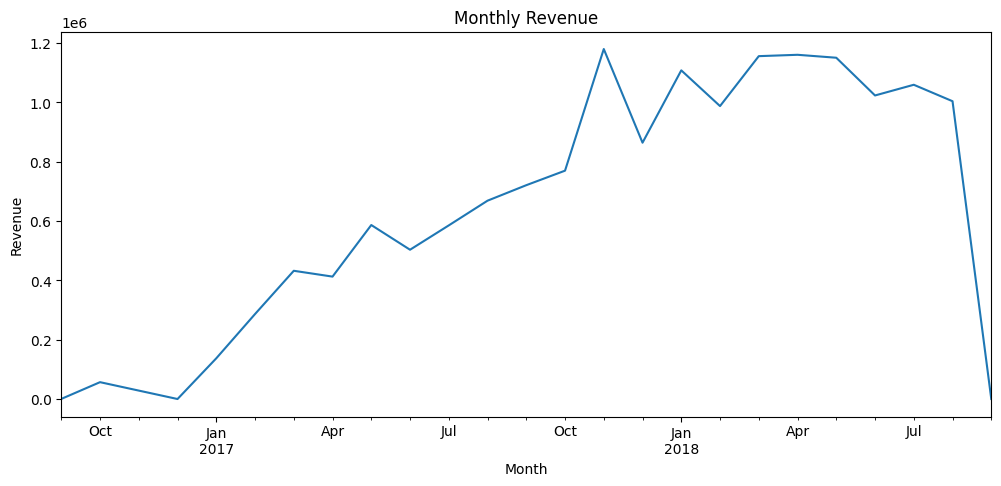

```python
plt.figure(figsize=(12,5))

revenue_per_month.plot()

plt.title("Monthly Revenue")
plt.xlabel("Month")
plt.ylabel("Revenue")

plt.show()
```

### **Order vs. Revenue Comparison**

We observe that revenue follows the same trends as orders.

The revenue trend closely follows the number of orders over time. This suggests that the average order value remains relatively stable across the analyzed period.

### **Comparaison commandes vs chiffre d’affaires**

L'évolution du chiffre d'affaires suit de près celle du nombre de commandes au fil du temps.

Cela signifie probablement que, le panier moyen reste relativement stable dans le temps en effet si les commandes augmentent, les revenus augmentent proportionnellement, nous pouvons en conclure que les clients dépensent à peu près la même somme par commande.

### **Mois ayant généré le plus de chiffre d'affaire**

Dans l’e-commerce, plusieurs facteurs peuvent expliquer un pic, promotions, saisonnalité, événements commerciaux ...

```python
# To confirm our graph, check the month
# Pour confirmer notre graphique, vérification du mois

revenue_per_month.sort_values(ascending=False).head()
```

```
order_month
2017-11    1179143.77
2018-04    1159698.04
2018-03    1155126.82
2018-05    1149781.82
2018-01    1107301.89
Freq: M, Name: revenue, dtype: float64
```

So far, we've been able to analyze order volume, overall revenue, and trends over time.  
But what we really want to know is which products generate the most revenue?

Jusqu’ici nous avons pu analyser, le volume des commandes, le revenu global et l'évolution temporelle  
Mais ce que nous souhaitons surtout savoir c'est quels produits génèrent le plus de revenus ?

```python
sales = pd.merge(
    sales,
    products,
    on="product_id",
    how="left"
)
```

```python
sales.head()
```

|  | order_id | customer_id | order_status | order_purchase_timestamp | order_approved_at | order_delivered_carrier_date | order_delivered_customer_date | order_estimated_delivery_date | month | order_purchase_month | ... | revenue | order_month | product_category_name | product_name_lenght | product_description_lenght | product_photos_qty | product_weight_g | product_length_cm | product_height_cm | product_width_cm |
| --- | --- | --- | --- | --- | --- | --- | --- | --- | --- | --- | --- | --- | --- | --- | --- | --- | --- | --- | --- | --- | --- |
| 0 | e481f51cbdc54678b7cc49136f2d6af7 | 9ef432eb6251297304e76186b10a928d | delivered | 2017-10-02 10:56:33 | 2017-10-02 11:07:15 | 2017-10-04 19:55:00 | 2017-10-10 21:25:13 | 2017-10-18 00:00:00 | 2017-10 | 2017-10 | ... | 38.71 | 2017-10 | utilidades_domesticas | 40.0 | 268.0 | 4.0 | 500.0 | 19.0 | 8.0 | 13.0 |
| 1 | 53cdb2fc8bc7dce0b6741e2150273451 | b0830fb4747a6c6d20dea0b8c802d7ef | delivered | 2018-07-24 20:41:37 | 2018-07-26 03:24:27 | 2018-07-26 14:31:00 | 2018-08-07 15:27:45 | 2018-08-13 00:00:00 | 2018-07 | 2018-07 | ... | 141.46 | 2018-07 | perfumaria | 29.0 | 178.0 | 1.0 | 400.0 | 19.0 | 13.0 | 19.0 |
| 2 | 47770eb9100c2d0c44946d9cf07ec65d | 41ce2a54c0b03bf3443c3d931a367089 | delivered | 2018-08-08 08:38:49 | 2018-08-08 08:55:23 | 2018-08-08 13:50:00 | 2018-08-17 18:06:29 | 2018-09-04 00:00:00 | 2018-08 | 2018-08 | ... | 179.12 | 2018-08 | automotivo | 46.0 | 232.0 | 1.0 | 420.0 | 24.0 | 19.0 | 21.0 |
| 3 | 949d5b44dbf5de918fe9c16f97b45f8a | f88197465ea7920adcdbec7375364d82 | delivered | 2017-11-18 19:28:06 | 2017-11-18 19:45:59 | 2017-11-22 13:39:59 | 2017-12-02 00:28:42 | 2017-12-15 00:00:00 | 2017-11 | 2017-11 | ... | 72.20 | 2017-11 | pet_shop | 59.0 | 468.0 | 3.0 | 450.0 | 30.0 | 10.0 | 20.0 |
| 4 | ad21c59c0840e6cb83a9ceb5573f8159 | 8ab97904e6daea8866dbdbc4fb7aad2c | delivered | 2018-02-13 21:18:39 | 2018-02-13 22:20:29 | 2018-02-14 19:46:34 | 2018-02-16 18:17:02 | 2018-02-26 00:00:00 | 2018-02 | 2018-02 | ... | 28.62 | 2018-02 | papelaria | 38.0 | 316.0 | 4.0 | 250.0 | 51.0 | 15.0 | 15.0 |

5 rows × 26 columns

```python
category_translation = pd.read_csv("../input/datasets/organizations/olistbr/brazilian-ecommerce/product_category_name_translation.csv")
```

```python
sales = pd.merge(
    sales,
    category_translation,
    on="product_category_name",
    how="left"
)
```

```python
# Now we can analyze the categories
# Maintenant on peut analyser les catégories

revenue_by_category = sales.groupby("product_category_name")["revenue"].sum().sort_values(ascending=False)
```

```python
revenue_by_category.head(10)
```

```
product_category_name
beleza_saude              1441248.07
relogios_presentes        1305541.61
cama_mesa_banho           1241681.72
esporte_lazer             1156656.48
informatica_acessorios    1059272.40
moveis_decoracao           902511.79
utilidades_domesticas      778397.77
cool_stuff                 719329.95
automotivo                 685384.32
ferramentas_jardim         584219.21
Name: revenue, dtype: float64
```

### **Top 5 categories by revenue**

| Rang | Catégory | Revenue |
| --- | --- | --- |
| 1 | health_beauty | 1.44M |
| 2 | watches_gifts | 1.30M |
| 3 | bed_bath_table | 1.24M |
| 4 | sports_leisure | 1.15M |
| 5 | computers_accessories | 1.05M |

These five categories represent the economic drivers of the marketplace

Health & Beauty products generate the highest revenue on the marketplace, followed by Watches & Gifts and Bed, Bath & Table items. These categories likely benefit from strong consumer demand and frequent purchases. Technology-related products such as computer accessories also contribute significantly to revenue, suggesting that electronics are an important segment of the platform.

--

### **Top 5 des catégories par chiffre d’affaires**

| Rang | Catégory | Revenue |
| --- | --- | --- |
| 1 | health_beauty | 1.44M |
| 2 | watches_gifts | 1.30M |
| 3 | bed_bath_table | 1.24M |
| 4 | sports_leisure | 1.15M |
| 5 | computers_accessories | 1.05M |

Ces cinq catégories représentent les moteurs économiques de la marketplace

Les produits de santé et de beauté génèrent le chiffre d'affaires le plus important sur la plateforme, suivis par les montres et cadeaux, puis par le linge de maison, de bain et de table. Ces catégories bénéficient probablement d'une forte demande des consommateurs et d'achats fréquents. Les produits technologiques, tels que les accessoires informatiques, contribuent également de manière significative au chiffre d'affaires, ce qui indique que l'électronique représente un segment important de la plateforme.

The marketplace revenue is largely driven by everyday consumer products such as beauty items and household goods. These categories tend to generate steady demand and frequent purchases. Technology-related products and gift-oriented categories also play a significant role in overall revenue generation.

Le chiffre d'affaires de la plateforme est principalement généré par les produits de consommation courante, tels que les articles de beauté et les produits ménagers. Ces catégories bénéficient généralement d'une demande stable et d'achats fréquents. Les produits technologiques et les articles cadeaux contribuent également de manière significative au chiffre d'affaires global.

So far, we've been able to analyze:

- orders
- revenue
- product categories

But we also need to monitor customer satisfaction on the marketplace, and this dataset contains customer reviews. Therefore, we'll be able to analyze the relationship between deliveries, customer ratings, logistics, and customer satisfaction and experience.

--

Jusqu’ici nous avons pu analyser les :

- commandes
- revenus
- catégories produits

Mais nous devons également surveiller la satisfaction client de la marketplace et ce dataset contient les avis clients. Nous allons donc pouvoir analyser la relation entre les livraisons, les notes client, la logistique avec la satisfaction et l'expérience client.

```python
sales = pd.merge(
    sales,
    order_reviews,
    on="order_id",
    how="left"
)
```

```python
sales[["review_score"]].describe()
```

|  | review_score |
| --- | --- |
| count | 112372.000000 |
| mean | 4.032473 |
| std | 1.387849 |
| min | 1.000000 |
| 25% | 4.000000 |
| 50% | 5.000000 |
| 75% | 5.000000 |
| max | 5.000000 |

```python
sales["review_score"].value_counts().sort_index()
```

```
review_score
1.0    14235
2.0     3874
3.0     9423
4.0    21315
5.0    63525
Name: count, dtype: int64
```

### **1️. Distribution of customer reviews - Distribution des avis clients**

| Rang | Nombre |
| --- | --- |
| ⭐ 1 | 14235 |
| ⭐ 2 | 3874 |
| ⭐ 3 | 9423 |
| ⭐ 4 | 21315 |
| ⭐ 5 | 63525 |

Total ≈ 112 372 avis.

### **2️. Quick calculation of proportions - Calcul rapide des proportions**

we can approximate - On peut approximer :

| Rang | % |
| --- | --- |
| ⭐ 5 | ~56 % |
| ⭐ 4 | ~19 % |
| ⭐ 3 | ~8 % |
| ⭐ 2 | ~3 % |
| ⭐ 1 | ~13 % |

### **3. Insight principal**

Customer satisfaction appears generally high on the platform. More than 75% of reviews are rated 4 or 5 stars, indicating that most customers had a positive experience.

La satisfaction client semble globalement élevée sur la plateforme. Plus de 75 % des avis sont notés 4 ou 5 étoiles, ce qui indique que la plupart des clients ont eu une expérience positive.

### **4️. However - Cependant :**

The number of 1-star reviews remains high (~14k). This is a critical point. This means that a significant proportion of customers encountered a problem or had a negative experience, a substantial number that needs to be analyzed to understand the reasons why.

Le nombre de notes 1 étoile reste élevé (~14k). C’est un point critique. Cela signifie qu’une part non négligeable des clients, ont rencontré un problème, ont vécu une mauvaise expérience, part importante qu'il faut analyser pour en comprendre la raison

### **5️. Analytical hypothesis - Hypothèse analytique**

One hypothesis that could be logical in e-commerce is that poor ratings could be linked to delivery delays. Since our dataset contains information on the expected delivery date and the actual delivery date, we can test this hypothesis.

Une hypothèse qui pourrait être logique dans l’e-commerce, les mauvaises notes pourraient être liées à des retards de livraison. Nous avons dans le dataset une information sur la date prévue de livraison et la date réelle de livraison, nous pouvons donc tester cette hypothèse.

```python
# Next step — calculate delivery times
# Étape suivante — calculer les délais de livraison

sales["delivery_time"] = (
    sales["order_delivered_customer_date"] - sales["order_purchase_timestamp"]
).dt.days
```

```python
date_columns = [
    "order_purchase_timestamp",
    "order_approved_at",
    "order_delivered_carrier_date",
    "order_delivered_customer_date",
    "order_estimated_delivery_date"
]

for col in date_columns:
    orders[col] = pd.to_datetime(orders[col])
```

```python
date_columns = [
    "order_purchase_timestamp",
    "order_approved_at",
    "order_delivered_carrier_date",
    "order_delivered_customer_date",
    "order_estimated_delivery_date"
]

for col in date_columns:
    orders[col] = pd.to_datetime(orders[col])
```

```python
sales = pd.merge(
    orders,
    order_items,
    on="order_id",
    how="inner"
)
```

```python
sales[[
    "order_purchase_timestamp",
    "order_delivered_customer_date",
    "order_estimated_delivery_date"
]].info()
```

```
<class 'pandas.core.frame.DataFrame'>
RangeIndex: 112650 entries, 0 to 112649
Data columns (total 3 columns):
 #   Column                         Non-Null Count   Dtype
---  ------                         --------------   -----
 0   order_purchase_timestamp       112650 non-null  datetime64[ns]
 1   order_delivered_customer_date  110196 non-null  datetime64[ns]
 2   order_estimated_delivery_date  112650 non-null  datetime64[ns]
dtypes: datetime64[ns](3)
memory usage: 2.6 MB
```

```python
sales["delivery_delay"] = (
    sales["order_delivered_customer_date"] - sales["order_estimated_delivery_date"]
).dt.days
```

```python
date_columns = [
    "order_purchase_timestamp",
    "order_approved_at",
    "order_delivered_carrier_date",
    "order_delivered_customer_date",
    "order_estimated_delivery_date"
]

for col in date_columns:
    orders[col] = pd.to_datetime(orders[col])

sales = pd.merge(
    orders,
    order_items,
    on="order_id",
    how="inner"
)

sales["delivery_delay"] = (
    sales["order_delivered_customer_date"] - sales["order_estimated_delivery_date"]
).dt.days
```

```python
# 1. Convert date columns in orders
date_columns = [
    "order_purchase_timestamp",
    "order_approved_at",
    "order_delivered_carrier_date",
    "order_delivered_customer_date",
    "order_estimated_delivery_date"
]

for col in date_columns:
    orders[col] = pd.to_datetime(orders[col])

# 2. Build sales table from orders + order items
sales = pd.merge(
    orders,
    order_items,
    on="order_id",
    how="inner"
)

# 3. Add reviews back into sales
sales = pd.merge(
    sales,
    order_reviews[["order_id", "review_score"]],
    on="order_id",
    how="left"
)

# 4. Compute delivery delay
sales["delivery_delay"] = (
    sales["order_delivered_customer_date"] - sales["order_estimated_delivery_date"]
).dt.days

# 5. Average delivery delay by review score
sales.groupby("review_score")["delivery_delay"].mean()
```

```
review_score
1.0    -5.965336
2.0    -9.735946
3.0   -11.079195
4.0   -12.481968
5.0   -13.427393
Name: delivery_delay, dtype: float64
```

### **1. Interpretation of values - Interprétation des valeurs**

| Rang | Average delay (days) |
| --- | --- |
| ⭐ 1 | -5.96 |
| ⭐ 2 | -9.73 |
| ⭐ 3 | -11.07 |
| ⭐ 4 | -12.48 |
| ⭐ 5 | -13.43 |

Note : delivery_delay = actual delivery - estimated delivery  
Note : delivery_delay = livraison réelle - livraison estimée

| value | meaning |
| --- | --- |
| negatif | delivered early |
| 0 | delivered on time |
| positive | delivered late |

### **2️. What the results show - Ce que montrent les résultats**

All values are negative. Orders are on average delivered before the estimated date.

Toutes les valeurs sont négatives. Les commandes sont en moyenne livrées avant la date estimée.

But what is very interesting to note is  
Mais ce qui est très intéressant à relever :

| Rang | Average advance |
| --- | --- |
| ⭐ 1 | ~6 jours |
| ⭐ 5 | ~13 jours |

We observe that the earlier the delivery is made, the better the customer rating.  
On constate que plus la livraison est anticipée, meilleure est la note client.

### **3️. Insight analytique**

Customer satisfaction appears strongly related to delivery performance. Orders with 5-star reviews were delivered on average about 13 days earlier than the estimated delivery date. In contrast, orders with 1-star reviews were delivered only about 6 days earlier than expected. This suggests that faster deliveries significantly improve customer satisfaction.

La satisfaction client semble fortement liée à la performance de la livraison. Les commandes ayant reçu une note de 5 étoiles ont été livrées en moyenne 13 jours plus tôt que prévu. À l'inverse, les commandes ayant reçu une note d'une étoile ont été livrées seulement 6 jours plus tôt que prévu. Cela suggère que des livraisons plus rapides améliorent significativement la satisfaction client.

### **4️. However, it's important to note a key distinction: we cannot conclude that lateness equals a bad grade**

Because in the dataset, the majority of orders arrive before the scheduled date. However, we can conclude that the faster the delivery, the better the customer satisfaction.

Néanmoins, attention à une nuance importante, on ne peut pas conclure que : retard = mauvaise note, car dans le dataset, la majorité des commandes arrivent avant la date prévue. Par contre nous pouvons conclure que plus la livraison est rapide, meilleure est la satisfaction client.

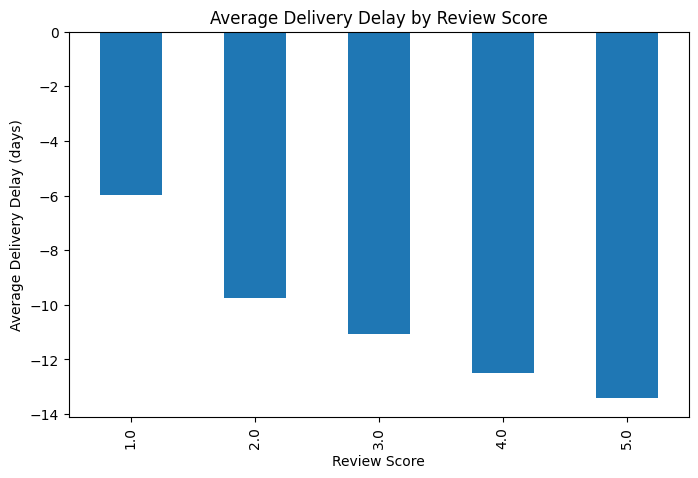

```python
# Creating the graph
# Création du graphique

plt.figure(figsize=(8,5))

sales.groupby("review_score")["delivery_delay"].mean().plot(kind="bar")

plt.title("Average Delivery Delay by Review Score")
plt.xlabel("Review Score")
plt.ylabel("Average Delivery Delay (days)")

plt.show()
```

### Cet analyse relie trois dimensions business :

- Logistique
- Expérience client
- Satisfaction

### **Average Order Value Analysis**

Average order value is a key performance indicator (KPI) in e-commerce. Formula: Average Order Value = Total Revenue / Number of Orders

### **Analyse du panier moyen (Average Order Value)**

Le panier moyen est un KPI clé en e-commerce. Formule : Panier moyen = Chiffre d'affaires total / Nombre de commandes

```python
# Calculate revenue per order
# Since an order can contain multiple products, the rows in the sales table must be aggregated.

# Calculer le chiffre d’affaires par commande
# Comme une commande peut contenir plusieurs produits, il faut agréger les lignes de la table sales.

sales["revenue"] = sales["price"] + sales["freight_value"]
```

```python
order_revenue = sales.groupby("order_id")["revenue"].sum()
```

```python
average_order_value = order_revenue.mean()
average_order_value
```

```
np.float64(161.3106066932885)
```

### **1️. Average Order Value**

161.31 BRL  
The average order value is approximately 161 BRL. This means that, on average, a customer spends 161 Brazilian reais per order.

### **2️. Analytical Interpretation**

The average order value on the marketplace is approximately 161 BRL. This indicates that customers typically spend around this amount per transaction. Understanding the average order value helps businesses evaluate purchasing behavior and identify opportunities to increase revenue through strategies such as product bundling or cross-selling.

### **3️. Why this KPI is important**

In e-commerce, three indicators are fundamental:

| KPI | signification |
| --- | --- |
| Orders | volume of activity |
| Average Order Value | average expenditure |
| Revenue | financial performance |

Companies often use the following formula :  
Revenue = Orders × Average Order Value

Improving the average order value is a classic strategy.  
For example: product bundles, recommendations, free shipping above a certain threshold

### **4️. Observation**

Since the average order value remains relatively stable, revenue growth appears primarily driven by an increase in the number of orders rather than higher spending per purchase.

--

### **1️. Panier moyen (Average Order Value)**

161.31 BRL  
Le panier moyen est d’environ 161 BRL Cela signifie qu'en moyenne, un client dépense 161 réais brésiliens par commande.

### **2️. Interprétation analytique**

Le panier moyen sur la plateforme est d'environ 161 BRL. Comprendre le panier moyen permet aux entreprises d'analyser les comportements d'achat, d'identifier les opportunités et d'accroître leur chiffre d'affaires grâce à des stratégies telles que la vente groupée ou la vente croisée.

### **3️. Pourquoi ce KPI est important**

Dans le e-commerce, trois indicateurs sont fondamentaux :

| KPI | signification |
| --- | --- |
| Orders | volume d’activité |
| Average Order Value | dépense moyenne |
| Revenue | performance financière |

Les entreprises utilisent souvent la formule :  
Revenue = Orders × Average Order Value

Améliorer le panier moyen est une stratégie classique. Par exemple : bundles produits, recommandations, livraison gratuite au-dessus d’un seuil

### **4️. Observation**

Etant donné que la valeur moyenne des commandes reste relativement stable, la croissance du chiffre d'affaires semble principalement due à une augmentation du nombre de commandes plutôt qu'à une hausse des dépenses par achat.

## **Analyse géographique**

```python
# Adding customer location
# Ajout de la localisation client

sales = pd.merge(
    sales,
    customers[["customer_id", "customer_state"]],
    on="customer_id",
    how="left"
)
```

```python
# State revenue calculation
# Calcul du revenu par état

sales = pd.merge(
    sales,
    customers[["customer_id", "customer_state"]],
    on="customer_id",
    how="left"
)
```

```python
# Graph generation
# Génération du graphique

sales = pd.merge(
    sales,
    customers[["customer_id", "customer_state"]],
    on="customer_id",
    how="left"
)
```

```python
sales.columns
```

```
Index(['order_id', 'customer_id', 'order_status', 'order_purchase_timestamp',
       'order_approved_at', 'order_delivered_carrier_date',
       'order_delivered_customer_date', 'order_estimated_delivery_date',
       'month', 'order_purchase_month', 'order_item_id', 'product_id',
       'seller_id', 'shipping_limit_date', 'price', 'freight_value',
       'review_score', 'delivery_delay', 'revenue', 'customer_state_x',
       'customer_state_y', 'customer_state'],
      dtype='object')
```

```python
[col for col in sales.columns if "customer_state" in col]
```

```
['customer_state_x', 'customer_state_y', 'customer_state']
```

```python
sales[["customer_state_x", "customer_state_y"]].head()
```

|  | customer_state_x | customer_state_y |
| --- | --- | --- |
| 0 | SP | SP |
| 1 | BA | BA |
| 2 | GO | GO |
| 3 | RN | RN |
| 4 | SP | SP |

```python
date_columns = [
    "order_purchase_timestamp",
    "order_approved_at",
    "order_delivered_carrier_date",
    "order_delivered_customer_date",
    "order_estimated_delivery_date"
]

for col in date_columns:
    orders[col] = pd.to_datetime(orders[col])

# Build final analytical table
sales = pd.merge(orders, order_items, on="order_id", how="inner")
sales = pd.merge(sales, order_reviews[["order_id", "review_score"]], on="order_id", how="left")
sales = pd.merge(sales, products, on="product_id", how="left")
sales = pd.merge(sales, customers[["customer_id", "customer_state"]], on="customer_id", how="left")

# Create key metrics
sales["revenue"] = sales["price"] + sales["freight_value"]
sales["delivery_delay"] = (
    sales["order_delivered_customer_date"] - sales["order_estimated_delivery_date"]
).dt.days
```

```python
revenue_by_state = sales.groupby("customer_state")["revenue"].sum().sort_values(ascending=False)
revenue_by_state.head(10)
```

```
customer_state
SP    5951489.17
RJ    2139076.28
MG    1863794.44
RS     890763.29
PR     804321.70
BA     613777.23
SC     612153.65
DF     355792.69
GO     351160.09
ES     325949.95
Name: revenue, dtype: float64
```

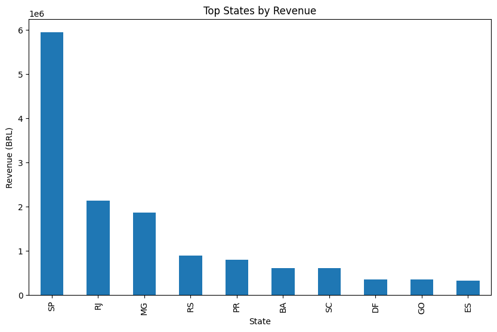

```python
plt.figure(figsize=(10,6))
revenue_by_state.head(10).plot(kind="bar")
plt.title("Top States by Revenue")
plt.xlabel("State")
plt.ylabel("Revenue (BRL)")
plt.show()
```

```python
revenue_by_state.head(10)
```

```
customer_state
SP    5951489.17
RJ    2139076.28
MG    1863794.44
RS     890763.29
PR     804321.70
BA     613777.23
SC     612153.65
DF     355792.69
GO     351160.09
ES     325949.95
Name: revenue, dtype: float64
```

### **1️. Top 5 states by revenue**

Le top 5 des états par revenu

| State | Revenue (BRL) |
| --- | --- |
| SP | 5.95M |
| RJ | 2.13M |
| MG | 1.86M |
| RS | 0.89M |
| PR | 0.80M |

The others follow with smaller amounts.  
Les autres suivent avec des montants plus faibles.

### **2️. Key Insight**

São Paulo dominates sales by a wide margin. Revenue generated by SP represents almost 6 million BRL, or approximately :  
≈ 37% of total sales

São Paulo domine très largement les ventes. Le revenu généré par SP représente presque 6 millions BRL, soit environ :  
≈ 37 % du chiffre d'affaires total

### **3. Economic interpretation**

These results are logical because these states are among the most important in Brazil:  
Ces résultats sont logiques car ces états sont parmi les plus importants du Brésil :

| State | Economic importance |
| --- | --- |
| SP | economic center of the country |
| RJ | major city |
| MG | large population |
| RS | strong regional economy |
| PR | Industrial state |

Les revenus sont fortement concentrés dans les États brésiliens les plus développés sur le plan économique. À lui seul, São Paulo génère près de 6 millions de BRL de revenus, ce qui en fait de loin le plus grand marché de la plateforme. Rio de Janeiro et Minas Gerais sont également des contributeurs importants. Cela suggère que l'activité du marché est fortement corrélée à la densité de population et au développement économique régional.

Revenue is highly concentrated in the most economically developed Brazilian states. São Paulo alone generates nearly 6 million BRL in revenue, making it by far the largest market on the platform. Other major contributors include Rio de Janeiro and Minas Gerais. This suggests that marketplace activity is strongly correlated with population density and regional economic development.

### **4. observation**

The top 3 states (SP, RJ, MG) account for a very large share of the income.  
This may indicate a concentration of demand or a concentration of sellers and more efficient logistics in these regions.

Les 3 premiers États (SP, RJ, MG) représentent une très grande part du revenu. Cela peut indiquer une concentration de la demande ou concentration des vendeurs et une logistique plus efficace dans ces régions

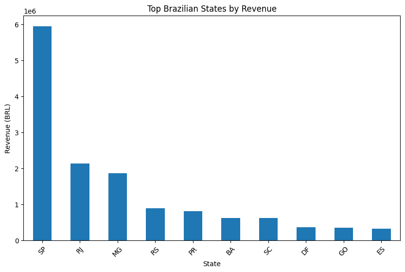

```python
plt.figure(figsize=(10,6))

revenue_by_state.head(10).plot(kind="bar")

plt.title("Top Brazilian States by Revenue")
plt.xlabel("State")
plt.ylabel("Revenue (BRL)")
plt.xticks(rotation=45)

plt.show()
```

## We still need one very important analysis for a marketplace: seller analysis

- Which sellers generate the most revenue?
- Does the marketplace depend on a few sellers?
- Is the distribution of revenue balanced?

## Il nous manque encore une analyse très importante pour une marketplace : l'analyse des vendeurs

- quels vendeurs génèrent le plus de revenus ?
- la marketplace dépend-elle de quelques vendeurs ?
- la distribution du revenu est-elle équilibrée ?

```python
# Concentration of income by seller. The order_items table already contains seller_id,
# and in most cases we already have the data in sales. Let's check:

# Concentration du revenu par vendeur. La table order_items contient déjà seller_id,
# dans la plupart des cas nous avons déjà les données dans sales. Vérifions :

"seller_id" in sales.columns
```

```
True
```

```python
# Calculation of income per salesperson
# Calcul du revenu par vendeur

revenue_by_seller = sales.groupby("seller_id")["revenue"].sum().sort_values(ascending=False)

revenue_by_seller.head(10)
```

```
seller_id
4869f7a5dfa277a7dca6462dcf3b52b2    249640.70
7c67e1448b00f6e969d365cea6b010ab    241374.82
4a3ca9315b744ce9f8e9374361493884    238440.31
53243585a1d6dc2643021fd1853d8905    235856.68
fa1c13f2614d7b5c4749cbc52fecda94    204084.73
da8622b14eb17ae2831f4ac5b9dab84a    188062.51
7e93a43ef30c4f03f38b393420bc753a    182754.05
1025f0e2d44d7041d6cf58b6550e0bfa    174710.82
7a67c85e85bb2ce8582c35f2203ad736    163278.78
955fee9216a65b617aa5c0531780ce60    160694.86
Name: revenue, dtype: float64
```

```python
# How many sellers are there in the marketplace?
# Combien y a-t-il de vendeur dans la marketplace ?

sales["seller_id"].nunique()
```

```
3095
```

```python
# Calculation of income concentration
# Calcul de la concentration du revenu

seller_revenue_df = revenue_by_seller.reset_index()
seller_revenue_df.columns = ["seller_id", "revenue"]
```

```python
# Sorts sellers
# Trie des vendeurs

seller_revenue_df = seller_revenue_df.sort_values("revenue", ascending=False)
```

```python
# Calculation of cumulative income
# Calcul du revenu cumulatif

seller_revenue_df["cumulative_revenue"] = seller_revenue_df["revenue"].cumsum()
seller_revenue_df["cumulative_percentage"] = seller_revenue_df["cumulative_revenue"] / seller_revenue_df["revenue"].sum()
```

```python
# Revenue Concentration by Sellers

seller_revenue_df["seller_rank"] = range(1, len(seller_revenue_df) + 1)
seller_revenue_df["seller_percentage"] = seller_revenue_df["seller_rank"] / len(seller_revenue_df)
```

# **Chart (Pareto / 80-20 rule)**

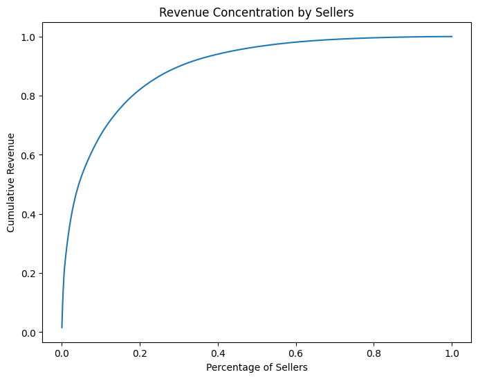

```python
plt.figure(figsize=(8,6))

plt.plot(
    seller_revenue_df["seller_percentage"],
    seller_revenue_df["cumulative_percentage"]
)

plt.title("Revenue Concentration by Sellers")
plt.xlabel("Percentage of Sellers")
plt.ylabel("Cumulative Revenue")

plt.show()
```

According to the Pareto principle: 20% of sellers generate 80% of revenue. Let's see if this is true in this marketplace.\

Selon le principe de Pareto : 20 % des vendeurs génèrent 80 % du revenu, vérifions si c’est vrai dans cette marketplace.

```python
seller_revenue_df.head()
```

|  | seller_id | revenue | cumulative_revenue | cumulative_percentage | seller_rank | seller_percentage |
| --- | --- | --- | --- | --- | --- | --- |
| 0 | 4869f7a5dfa277a7dca6462dcf3b52b2 | 249640.70 | 249640.70 | 0.015685 | 1 | 0.000323 |
| 1 | 7c67e1448b00f6e969d365cea6b010ab | 241374.82 | 491015.52 | 0.030851 | 2 | 0.000646 |
| 2 | 4a3ca9315b744ce9f8e9374361493884 | 238440.31 | 729455.83 | 0.045832 | 3 | 0.000969 |
| 3 | 53243585a1d6dc2643021fd1853d8905 | 235856.68 | 965312.51 | 0.060651 | 4 | 0.001292 |
| 4 | fa1c13f2614d7b5c4749cbc52fecda94 | 204084.73 | 1169397.24 | 0.073474 | 5 | 0.001616 |

```python
sales["seller_id"].nunique()
```

```
3095
```

### **1️. Number of sellers on the platform**

3,095 sellers

The Olist marketplace has around 3,000 active sellers. This is typical for a multi-seller marketplace.

### **2️. Revenue of the top seller**

249,640 BRL

Now let's compare this with the total revenue :  
≈ 15,843,553 BRL

So the top seller accounts for approximately :  
≈ 1.6% of total revenue

This is relatively low.

### **3. Important interpretation**

This suggests that the marketplace is not dominated by a single seller. The revenue seems to be relatively distributed among several sellers.

This is generally a good thing for a platform because it means:

- less dependence
- a more balanced ecosystem

--

### **1️. Nombre de vendeurs sur la plateforme**

3095 vendeurs

La marketplace Olist repose sur environ 3000 vendeurs actifs. C’est typique d’une marketplace multi-vendeurs.

### **2️. Revenu du vendeur n°1**

249 640 BRL

Maintenant comparons avec le revenu total :  
≈ 15 843 553 BRL

Le vendeur n°1 représente environ :  
≈ 1.6 % du revenu total

C’est relativement faible.

### **3️. Interprétation importante**

Cela suggère que la marketplace n’est pas dominée par un seul vendeur. Le revenu semble relativement distribué entre plusieurs vendeurs.

C’est généralement une bonne chose pour une plateforme car cela signifie :

- moins de dépendance
- écosystème plus équilibré

### How many salespeople generate 80% of revenue according to the famous Pareto principle?

### Combien de vendeurs génèrent 80 % du revenu selon le fameux principe de Pareto ?

```python
seller_revenue_df[seller_revenue_df["cumulative_percentage"] <= 0.8].shape
```

```
(561, 6)
```

| **Domain** | **Insight** | **Business interpretation** |
| --- | --- | --- |
| Marketplace Growth | Orders and revenue increased significantly between 2017 and 2018. | The platform is experiencing a phase of rapid growth. |
| Average Order Value | The average basket size is approximately 161 BRL | Revenue growth is mainly linked to an increase in the number of orders. |
| Top Product Categories | Les catégories Health & Beauty, Watches & Gifts et Bed & Bath génèrent le plus de revenus | Everyday products and gifts dominate demand |
| Customer Satisfaction | Over 75% of reviews are 4 or 5 stars | The overall customer experience is very positive. |
| Delivery Performance | 5-star orders are delivered on average 13 days before the estimated date. | Fast delivery greatly improves customer satisfaction |
| Geographic Concentration | The state of São Paulo generates approximately 37% of total revenue. | E-commerce activity is concentrated in the most developed regions. |
| Seller Ecosystem | The number 1 seller represents only 1.6% of total revenue | The marketplace is based on a relatively diverse ecosystem of sellers. |
| Revenue Distribution | A minority of sellers generate the majority of revenue (Pareto analysis) | Le modèle marketplace suit une logique classique de concentration |

| **Domaine** | **Insight** | **Interprétation business** |
| --- | --- | --- |
| Marketplace Growth | Les commandes et le chiffre d'affaires augmentent fortement entre 2017 et 2018 | La plateforme connaît une phase de croissance rapide |
| Average Order Value | Le panier moyen est d’environ 161 BRL | La croissance du revenu est principalement liée à l’augmentation du nombre de commandes |
| Top Product Categories | Les catégories Health & Beauty, Watches & Gifts et Bed & Bath génèrent le plus de revenus | Les produits du quotidien et les cadeaux dominent la demande |
| Customer Satisfaction | Plus de 75 % des avis ont 4 ou 5 étoiles | L'expérience client est globalement très positive |
| Delivery Performance | Les commandes 5 étoiles sont livrées en moyenne 13 jours avant la date estimée | Une livraison rapide améliore fortement la satisfaction client |
| Geographic Concentration | L'État de São Paulo génère environ 37 % du revenu total | L'activité e-commerce est concentrée dans les régions les plus développées |
| Seller Ecosystem | Le vendeur n°1 représente seulement 1.6 % du revenu total | La marketplace repose sur un écosystème de vendeurs relativement diversifié |
| Revenue Distribution | Une minorité de vendeurs génère la majorité du revenu (analyse Pareto) | Le modèle marketplace suit une logique classique de concentration |

## **Conclusion finale**

Cette analyse du marché brésilien du e-commerce révèle plusieurs informations importantes concernant la performance et la structure de la plateforme.

Premièrement, le marché a connu une forte croissance entre 2017 et 2018, principalement due à une augmentation du nombre de commandes plutôt qu'à une hausse du panier moyen.

Deuxièmement, la demande de produits est largement concentrée sur les biens de consommation courante, tels que les produits de beauté et les articles ménagers, ce qui génère un comportement d'achat régulier.

La satisfaction client est généralement élevée, avec plus de 75 % des avis notés quatre ou cinq étoiles. La performance de la livraison semble jouer un rôle clé dans la satisfaction client, les livraisons plus rapides étant associées à de meilleures notes.

D'un point de vue géographique, le chiffre d'affaires est fortement concentré dans les États brésiliens les plus développés économiquement, en particulier São Paulo, qui représente la plus grande part des revenus du marché.

Enfin, l'écosystème des vendeurs apparaît relativement diversifié. Bien que certains vendeurs génèrent des revenus plus élevés, la plateforme n'est pas excessivement dépendante d'un seul vendeur, ce qui contribue à une structure de marché plus équilibrée. Globalement, la plateforme présente un fort potentiel de croissance, soutenu par une base de vendeurs diversifiée, une grande satisfaction client et une demande concentrée dans des catégories clés de produits de consommation.

## **Business Conclusions**

This analysis of the Brazilian e-commerce marketplace reveals several important insights about the platform's performance and structure.

First, the marketplace experienced strong growth between 2017 and 2018, driven primarily by an increase in the number of orders rather than higher spending per transaction. Second, product demand is largely concentrated in everyday consumer goods such as beauty products and household items, which generate consistent purchasing behavior.

Customer satisfaction is generally high, with more than 75% of reviews rated four or five stars. Delivery performance appears to play a key role in customer satisfaction, as faster deliveries are associated with higher review scores. From a geographic perspective, revenue is heavily concentrated in the most economically developed Brazilian states, particularly São Paulo, which represents the largest share of marketplace revenue.

Finally, the seller ecosystem appears relatively diversified. Although some sellers generate higher revenues, the platform is not overly dependent on a single vendor, which contributes to a more balanced marketplace structure.

Overall, the platform demonstrates strong growth potential supported by a diversified seller base, strong customer satisfaction, and demand concentrated in key consumer product categories.